# Crime Analysis

J.Wente

#Load data

#Overview The goal is to play with the easily accessible St. Paul Police incident database. We can pull data from several different sources to create probablistic models. At first glance, there really appears to be strong seasonality in the St. Paul crime data.

In this markdown, we’re going to make use of the available data, create some plots, and eventually test some crime forecasting models.

To acess the crime data, you’ll need a Socrata account and a key.

Run the weather data nd the econdata scripts first, but I’ll include those here as well. I am working on getting more and more data into here. At the moment, I am working on getting census data in here as well as twitter data for the St. Paul geocode.

#initial plots and modelling Firstly, most crimes seem to follow a very cyclical pattern between summer and winter. The adage that warmer temps and crimes like aggravated assualt seem to generally be true. We’ll plot a few graphs here to illustrate.

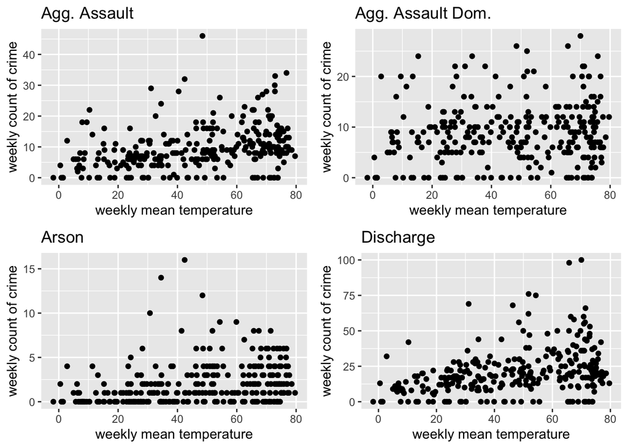

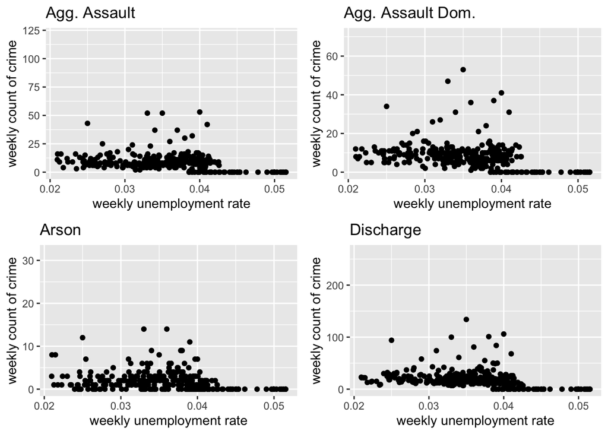